# Exercício 15 - Estatística Bayesiana

Vitor Bialetzki Cristiano

2026-09-12

# INTRODUÇÃO

Este relatório apresenta a resolução do **Exercício 15 (Módulo 1)** da disciplina de **Estatística Bayesiana**, ministrada pela Profa. Dra. Camila no Programa de Pós-Graduação da Universidade Federal de Viçosa (UFV). O objetivo deste estudo é caracterizar e modelar probabilisticamente a variável fenotípica **Rendimento de Grãos** (`Grain.Yield..bu.A.`), expressa em *bushels* por acre (bu/acre), proveniente do conjunto de dados de ensaios multiambientais do projeto *Genome to Fields* (G2F — safra 2018).

A produtividade de grãos é o caráter fenotípico de maior relevância agronômica e econômica na cultura do milho (*Zea mays* L.). Trata-se de uma variável quantitativa complexa, condicionada por múltiplos genes e fortemente influenciada pelas variações do meio e pela interação genótipo $\times$ ambiente ($G \times A$).

Para compreender o comportamento dessa variável, o rendimento foi tratado como uma **variável aleatória contínua** e modelado por meio de uma **Distribuição Normal** ($X \sim \ N (\mu, \sigma^2)$). A escolha desse modelo fundamentou-se na avaliação do ajuste de diversas distribuições candidatas, selecionando a Normal por apresentar os menores valores para os critérios de informação de Akaike (AIC) e Bayesiano (BIC).

## 15. As atividades deste exercício deverão ser realizadas com o auxílio do software R ou de outra linguagem de programação de escolha do(a) estudante, utilizando como referência as rotinas computacionais apresentadas na aula prática. Escolha uma variável aleatória relacionada à sua área de pesquisa e desenvolva as etapas a seguir.

### a) Definição da variável aleatória:

#### Apresente a variável aleatória escolhida e explique brevemente sua importância no contexto da sua área de pesquisa.

```r
Produtividade <- DadosPheno$Grain.Yield..bu.A.
head(Produtividade)
```

```
## [1]  76.20  95.25 115.57  99.06  86.36 109.22
```

A variável aleatória selecionada é o Rendimento de Grãos (Grain.Yield..bu.A.), mensurado em bushels por acre (bu/acre). Trata-se do caráter quantitativo de maior relevância agronômica e econômica na cultura do milho (*Zea mays* L.)

### b) Natureza e conjunto de valores possíveis:

#### Classifique a variável como discreta ou contínua e indique o conjunto de valores que ela pode assumir.

```r
range(DadosPheno$Grain.Yield..bu.A., na.rm = TRUE)
```

```
## [1]   9.81 370.70
```

```r
min(DadosPheno$Grain.Yield..bu.A., na.rm = TRUE)
```

```
## [1] 9.81
```

```r
max(DadosPheno$Grain.Yield..bu.A., na.rm = TRUE)
```

```
## [1] 370.7
```

```r
summary(DadosPheno$Grain.Yield..bu.A.)
```

```
##    Min. 1st Qu.  Median    Mean 3rd Qu.    Max.
##    9.81  124.83  155.31  154.96  185.05  370.70
```

```r
skim(DadosPheno$Grain.Yield..bu.A.)
```

Data summary

| Name | DadosPheno$Grain.Yield..b… |
| --- | --- |
| Number of rows | 24023 |
| Number of columns | 1 |
| _______________________ |  |
| Column type frequency: |  |
| numeric | 1 |
| ________________________ |  |
| Group variables | None |

**Variable type: numeric**

| skim_variable | n_missing | complete_rate | mean | sd | p0 | p25 | p50 | p75 | p100 | hist |
| --- | --- | --- | --- | --- | --- | --- | --- | --- | --- | --- |
| data | 0 | 1 | 154.96 | 43.53 | 9.81 | 124.83 | 155.31 | 185.05 | 370.7 | ▁▇▇▁▁ |

```r
describe(DadosPheno$Grain.Yield..bu.A.)
```

```
##    vars     n   mean    sd median trimmed   mad  min   max  range skew kurtosis
## X1    1 24023 154.96 43.53 155.31  154.94 44.64 9.81 370.7 360.89 0.01    -0.16
##      se
## X1 0.28
```

A variável produtividade é classificada como contínua e aleatória, pois se encontra em um intervalo infinito e nāo numerável.

### c) Escolha da distribuição de probabilidade:

#### Escolha uma distribuição de probabilidade que considere adequada para representar a variável e especifique seus parâmetros. Para este exercício, os valores dos parâmetros poderão ser definidos de forma subjetiva ou fictícia.

```r
#### ajustar distribuicoes
y <- Produtividade
fits <- list()
# 1. Normal
fits$norm <- tryCatch(fitdist(y, "norm"), error = function(e) NULL)

# 2. Logística
fits$logis <- tryCatch(fitdist(y, "logis"), error = function(e) NULL)

# 3. Cauchy
fits$cauchy <- tryCatch(fitdist(y, "cauchy"), error = function(e) NULL)

# 4. Uniforme
fits$unif <- tryCatch(fitdist(y, "unif"), error = function(e) NULL)

# 5. Weibull
fits$weibull <- tryCatch(fitdist(y, "weibull"), error = function(e) NULL)

# 6. Gama
fits$gamma <- tryCatch(fitdist(y, "gamma"), error = function(e) NULL)

# 7. Log-Normal
fits$lnorm <- tryCatch(fitdist(y, "lnorm"), error = function(e) NULL)

# 8. Exponencial
fits$exp <- tryCatch(fitdist(y, "exp"), error = function(e) NULL)

# 9. Log-Logística
fits$llogis <- tryCatch(fitdist(y, "llogis"), error = function(e) NULL)

# 10. Gama Inversa
fits$invgamma <- tryCatch(fitdist(y, "invgamma"), error = function(e) NULL)

# 11. Weibull Inversa
fits$invweibull <- tryCatch(fitdist(y, "invweibull"), error = function(e) NULL)

# 12. Normal Assimétrica
fits$snorm <- tryCatch(
  fitdist(y, "sn", start = list(xi = mean(y), omega = sd(y), alpha = 0)),
  error = function(e) NULL
)
res_individual <- data.frame(
  Modelo = character(),
  AIC = numeric(),
  BIC = numeric(),
  stringsAsFactors = FALSE
)

for (m in names(fits)) {
  if (!is.null(fits[[m]])) {
    res_individual <- rbind(res_individual, data.frame(
      Modelo = m,
      AIC = fits[[m]]$aic,
      BIC = fits[[m]]$bic
    ))
  } else {
    cat("Ajuste individual do modelo '", m, "' falhou/não convergiu.\n", sep = "")
  }
}

res_ordem <- res_individual[order(res_individual$AIC), ]
rownames(res_ordem) <- NULL
print(res_ordem)
```

```
##        Modelo      AIC      BIC
## 1        norm 249478.8 249495.0
## 2       snorm 249480.8 249505.1
## 3     weibull 249532.4 249548.5
## 4       logis 250193.4 250209.6
## 5       gamma 251097.3 251113.5
## 6      llogis 251963.9 251980.1
## 7       lnorm 253402.6 253418.7
## 8    invgamma 257820.8 257836.9
## 9      cauchy 259006.9 259023.0
## 10 invweibull 269991.1 270007.2
## 11       unif 282926.4 282942.6
## 12        exp 290350.6 290358.7
```

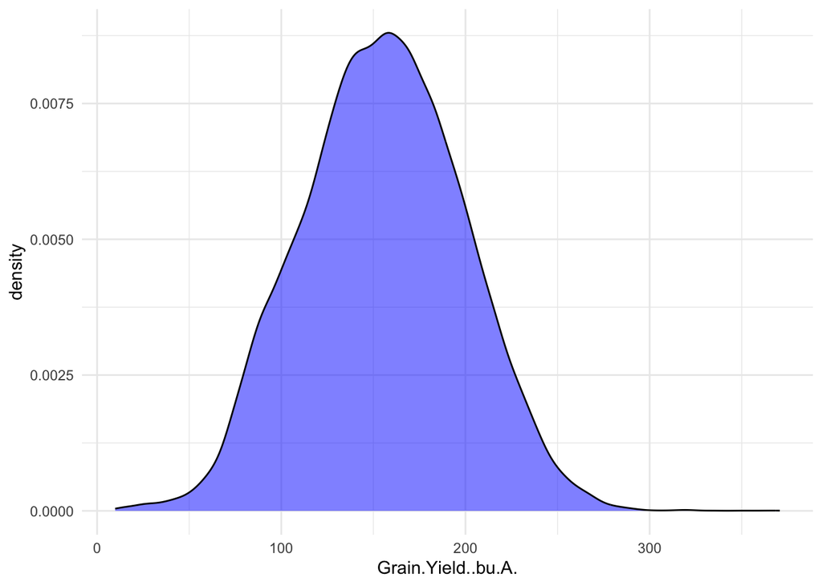

```r
###Graficos

ggplot(DadosPheno, aes(x = Grain.Yield..bu.A.)) +
  geom_density(fill = "blue", alpha = 0.5) +
  theme_minimal()
```

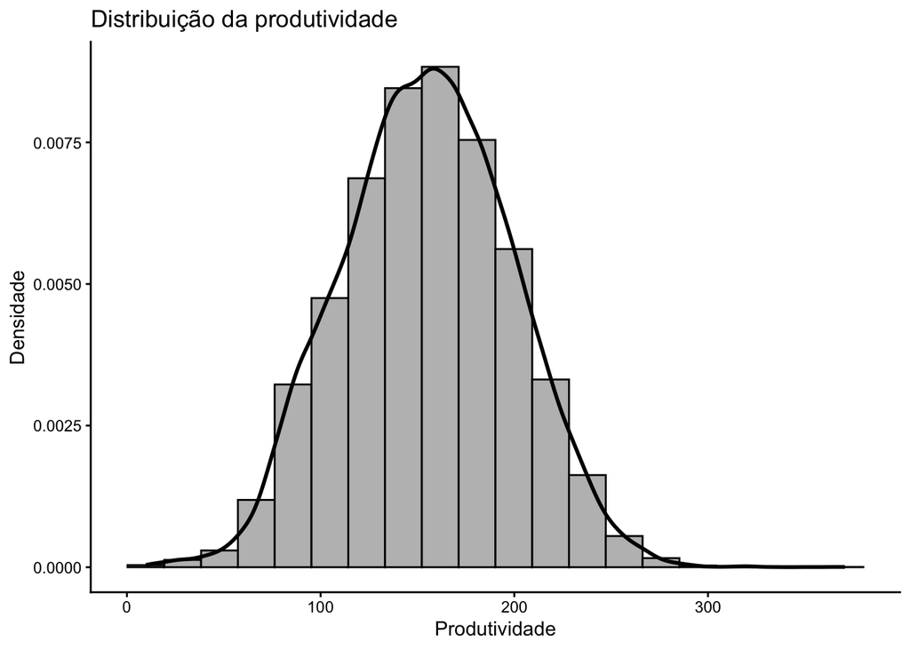

```r
ggplot(DadosPheno, aes(x = Grain.Yield..bu.A.)) +
  geom_histogram(aes(y = after_stat(density)),
                 bins = 20,
                 fill = "gray",
                 color = "black") +
  geom_density(linewidth = 1) +
  theme_classic() +
  labs(
    x = "Produtividade",
    y = "Densidade",
    title = "Distribuição da produtividade"
  )
```

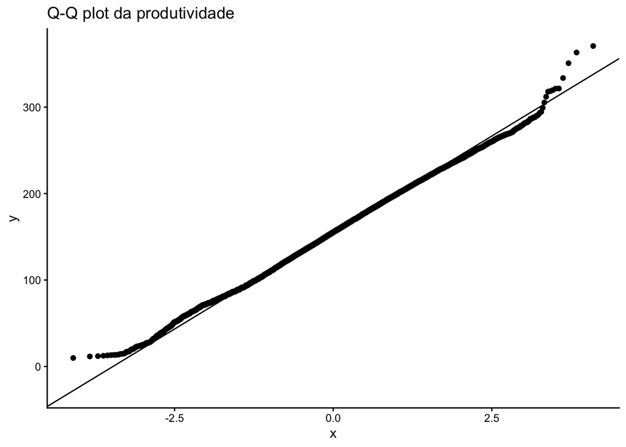

```r
ggplot(DadosPheno, aes(sample = Grain.Yield..bu.A.)) +
  stat_qq() +
  stat_qq_line() +
  theme_classic() +
  labs(
    title = "Q-Q plot da produtividade"
  )
```

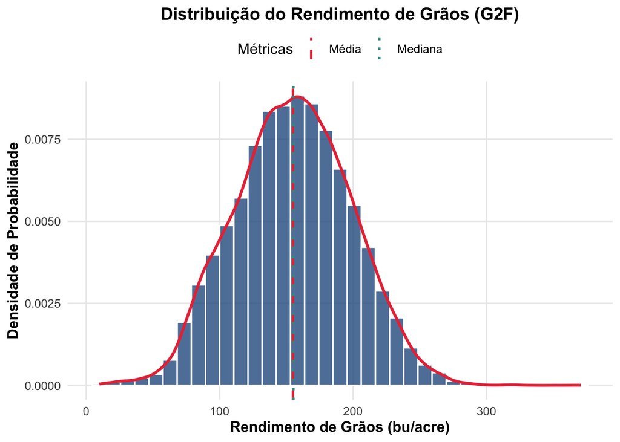

```r
media_prod <- mean(DadosPheno$Grain.Yield..bu.A)
mediana_prod <- median(DadosPheno$Grain.Yield..bu.A.)

ggplot(DadosPheno, aes(x = Grain.Yield..bu.A.)) +
  geom_histogram(
    aes(y = after_stat(density)),
    bins = 35,
    fill = "#2b5c8f",
    color = "white",
    alpha = 0.8
  ) +
  geom_density(color = "#e63946", linewidth = 1.1) +
  geom_vline(
    aes(xintercept = media_prod, linetype = "Média"),
    color = "#e63946", linewidth = 0.9
  ) +
  geom_vline(
    aes(xintercept = mediana_prod, linetype = "Mediana"),
    color = "#2a9d8f", linewidth = 0.9
  ) +
  scale_linetype_manual(
    name = "Métricas",
    values = c("Média" = "dashed", "Mediana" = "dotted")
  ) +
  labs(
    title = "Distribuição do Rendimento de Grãos (G2F)",
    x = "Rendimento de Grãos (bu/acre)",
    y = "Densidade de Probabilidade"
  ) +
  theme_minimal(base_size = 12) +
  theme(
    plot.title = element_text(face = "bold", size = 14, hjust = 0.5),
    plot.subtitle = element_text(size = 10, hjust = 0.5, color = "gray30"),
    axis.title = element_text(face = "bold"),
    legend.position = "top",
    panel.grid.minor = element_blank()
  )
```

```r
mean(DadosPheno$Grain.Yield..bu.A.)
```

```
## [1] 154.9556
```

```r
var(DadosPheno$Grain.Yield..bu.A.)
```

```
## [1] 1895.042
```

```r
KS_normal <-ks.test(DadosPheno$Grain.Yield..bu.A., "pnorm", mean = fits$norm$estimate["mean"], sd = fits$norm$estimate["sd"])
KS_normal$p.value
```

```
## [1] 0.006286823
```

### d) Justificativa da distribuição escolhida:

#### Justifique a escolha da distribuição com base nas características da variável e no mecanismo probabilístico associado ao fenômeno estudado.

A distribuição normal é adequada para representar a produtividade, pois os valores tendem a se concentrar em torno da média, com frequências progressivamente menores à medida que se afastam desse valor central. Dessa forma, assumimos que a produtividade pode ser representada por uma distribuição normal, caracterizada pela média $\mu$ e pela variância $\sigma^2$:

$$X \sim \ N (\mu,\sigma^2).$$

### e) Interpretação dos parâmetros:

#### Interprete, no contexto do problema, cada um dos parâmetros da distribuição escolhida.

A variável rendimento de grãos no dataset G2F foi modelada por uma distribuição normal, com parâmetros $\mu = 154{,}96$ bu/acre e $\sigma = 43{,}53$ bu/acre, sendo a variância dada por $\sigma^2 = 1895{,}04$ (bu/acre)$^2$:

$$X \sim \ N (154{,}96,\;1895{,}04).$$

$$\mu \pm 2\sigma
=
154{,}96 \pm 2(43{,}53),$$

resultando em aproximadamente:

$$67{,}90 \leq X \leq 242{,}02 \text{ bu/acre}.$$

Assim, espera-se que aproximadamente 95% dos valores de rendimento de grãos estejam entre 67,90 e 242,02 bu/acre, sob o modelo normal adotado.

### f) Função de probabilidade ou função densidade:

#### Apresente a expressão da:

##### - função de probabilidade, caso a variável seja discreta; ou

##### - função densidade de probabilidade, caso a variável seja contínua.

A distribuição normal é definida pela seguinte função densidade de probabilidade (f.d.p.):

$$f(x) =
\frac{1}{\sqrt{2\pi\sigma^2}}
\exp\left(
-\frac{(x-\mu)^2}{2\sigma^2}
\right),
\qquad -\infty < x < \infty.$$

em que $\mu$ representa a média da distribuição e $\sigma^2$ representa a variâcia.

### g) Representação gráfica da distribuição:

#### Construa o gráfico da função de probabilidade ou da função densidade de probabilidade e descreva as principais características observadas em sua forma.

```r
media_prod <- mean(DadosPheno$Grain.Yield..bu.A)
mediana_prod <- median(DadosPheno$Grain.Yield..bu.A.)
media_prod
```

```
## [1] 154.9556
```

```r
mediana_prod
```

```
## [1] 155.31
```

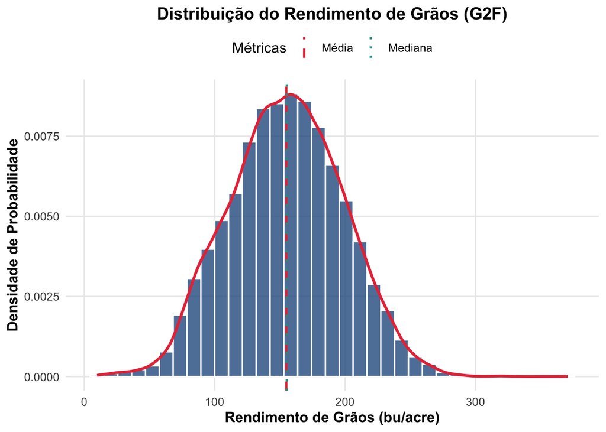

```r
ggplot(DadosPheno, aes(x = Grain.Yield..bu.A.)) +
  geom_histogram(
    aes(y = after_stat(density)),
    bins = 35,
    fill = "#2b5c8f",
    color = "white",
    alpha = 0.8
  ) +
  geom_density(color = "#e63946", linewidth = 1.1) +
  geom_vline(
    aes(xintercept = media_prod, linetype = "Média"),
    color = "#e63946", linewidth = 0.9
  ) +
  geom_vline(
    aes(xintercept = mediana_prod, linetype = "Mediana"),
    color = "#2a9d8f", linewidth = 0.9
  ) +
  scale_linetype_manual(
    name = "Métricas",
    values = c("Média" = "dashed", "Mediana" = "dotted")
  ) +
  labs(
    title = "Distribuição do Rendimento de Grãos (G2F)",
    x = "Rendimento de Grãos (bu/acre)",
    y = "Densidade de Probabilidade"
  ) +
  theme_minimal(base_size = 12) +
  theme(
    plot.title = element_text(face = "bold", size = 14, hjust = 0.5),
    plot.subtitle = element_text(size = 10, hjust = 0.5, color = "gray30"),
    axis.title = element_text(face = "bold"),
    legend.position = "top",
    panel.grid.minor = element_blank()
  )
```

A principal característica da distribuição normal é o seu formato de sino perfeitamente simétrico, onde a média, a mediana e a moda possuem o mesmo valor e ficam localizadas no centro da curva.

### h) Função de distribuição acumulada:

#### Apresente a função de distribuição acumulada associada à variável e construa seu gráfico.

A distribuição normal é definida pela seguinte função densidade de probabilidade (f.d.p.):

$$f(x) =
\frac{1}{\sqrt{2\pi\sigma^2}}
\exp\left(
-\frac{(x-\mu)^2}{2\sigma^2}
\right),
\qquad -\infty < x < \infty.$$

em que $\mu$ representa a média da distribuição e $\sigma^2$ representa a variâcia.

```r
yield_Alta <- dnorm(300, mean = 154.9555, sd = 42.9539)
yield_Alta
```

```
## [1] 3.103857e-05
```

```r
DA_alta <- pnorm(300, mean = 154.9555, sd = 42.9539, lower.tail = TRUE, log.p = FALSE)
DA_alta
```

```
## [1] 0.9996333
```

```r
yield_media <- dnorm(150, mean = 154.9555, sd = 42.9539)
yield_media
```

```
## [1] 0.009226082
```

```r
DA_media <- pnorm(150, mean = 154.9555, sd = 42.9539, lower.tail = TRUE, log.p = FALSE)
DA_media
```

```
## [1] 0.4540768
```

```r
yield_baixa <- dnorm(50, mean = 154.9555, sd = 42.9539)
yield_baixa
```

```
## [1] 0.0004692954
```

```r
DA_baixa <- pnorm(50, mean = 154.9555, sd = 42.9539, lower.tail = TRUE, log.p = FALSE)
DA_baixa
```

```
## [1] 0.00727389
```

```r
Quantil <-qnorm(0.95, mean = 154.9555, sd = 42.9539, lower.tail = TRUE, log.p = FALSE)
Quantil
```

```
## [1] 225.6084
```

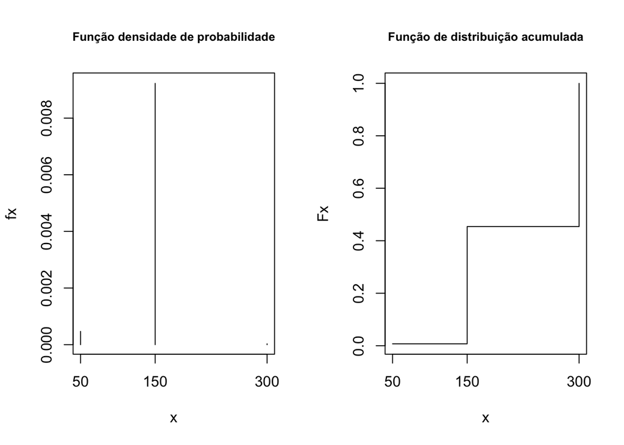

```r
par(mfrow = c(1, 2))

x = c(50, 150, 300)

fx = c(yield_baixa, yield_media, yield_Alta)

plot(x, fx,
     type = "h",
     main = "Função densidade de probabilidade",
     xaxt = "n",
     cex.main = 0.8)

axis(side = 1, at = c(50, 150, 300))

Fx = c(DA_baixa, DA_media, DA_alta)

plot(x, Fx,
     type = "s",
     main = "Função de distribuição acumulada",
     xaxt = "n",
     cex.main = 0.8)

axis(side = 1, at = c(50, 150, 300))
```

### i) Probabilidades de interesse:

#### Defina pelo menos três eventos de interesse prático relacionados à variável escolhida e calcule suas probabilidades utilizando a distribuição assumida. Para variáveis contínuas, inclua pelo menos uma probabilidade associada a um intervalo de valores.

```r
yield_Alta <- dnorm(300, mean = 154.9555, sd = 42.9539)
yield_Alta
```

```
## [1] 3.103857e-05
```

```r
DA_alta <- pnorm(300, mean = 154.9555, sd = 42.9539, lower.tail = TRUE, log.p = FALSE)
DA_alta
```

```
## [1] 0.9996333
```

```r
yield_media <- dnorm(150, mean = 154.9555, sd = 42.9539)
yield_media
```

```
## [1] 0.009226082
```

```r
DA_media <- pnorm(150, mean = 154.9555, sd = 42.9539, lower.tail = TRUE, log.p = FALSE)
DA_media
```

```
## [1] 0.4540768
```

```r
yield_baixa <- dnorm(50, mean = 154.9555, sd = 42.9539)
yield_baixa
```

```
## [1] 0.0004692954
```

```r
DA_baixa <- pnorm(50, mean = 154.9555, sd = 42.9539, lower.tail = TRUE, log.p = FALSE)
DA_baixa
```

```
## [1] 0.00727389
```

```r
Quantil <-qnorm(0.95, mean = 154.9555, sd = 42.9539, lower.tail = TRUE, log.p = FALSE)
Quantil
```

```
## [1] 225.6084
```

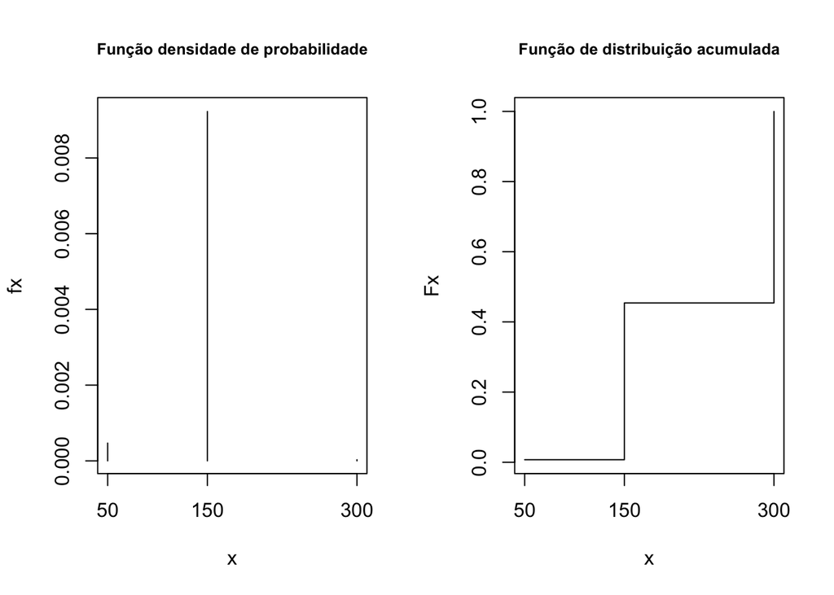

```r
par(mfrow = c(1, 2))

x = c(50, 150, 300)

fx = c(yield_baixa, yield_media, yield_Alta)

plot(x, fx,
     type = "h",
     main = "Função densidade de probabilidade",
     xaxt = "n",
     cex.main = 0.8)

axis(side = 1, at = c(50, 150, 300))

Fx = c(DA_baixa, DA_media, DA_alta)

plot(x, Fx,
     type = "s",
     main = "Função de distribuição acumulada",
     xaxt = "n",
     cex.main = 0.8)

axis(side = 1, at = c(50, 150, 300))
```

```r
mu <- 154.9556
var_val <- 1895.042

ex <- mu
mediana <- mu
moda <- mu
var_x <- var_val
dp_x <- sqrt(var_val)
cv_x <- (dp_x / ex) * 100

cat("E(X):       ", round(ex, 4), "bu/acre\n")
```

```
## E(X):        154.9556 bu/acre
```

```r
cat("Mediana(X): ", round(mediana, 4), "bu/acre\n")
```

```
## Mediana(X):  154.9556 bu/acre
```

```r
cat("Moda(X):    ", round(moda, 4), "bu/acre\n")
```

```
## Moda(X):     154.9556 bu/acre
```

```r
cat("Var(X):     ", round(var_x, 4), "(bu/acre)^2\n")
```

```
## Var(X):      1895.042 (bu/acre)^2
```

```r
cat("DP(X):      ", round(dp_x, 4), "bu/acre\n")
```

```
## DP(X):       43.5321 bu/acre
```

```r
cat("CV(X):      ", round(cv_x, 2), "%\n")
```

```
## CV(X):       28.09 %
```

### k) Quantis:

#### Determine pelo menos os seguintes quantis da distribuição: 𝑞0,25, 𝑞0,50, 𝑞0,75 𝑒 𝑞0,95. Interprete o significado de 𝑞0,50 e 𝑞0,95 no contexto da variável escolhida.

```r
quantis <- quantile(DadosPheno$Grain.Yield..bu.A., probs = c(0.25, 0.50, 0.75, 0.95), na.rm = TRUE)
quantis
```

```
##     25%     50%     75%     95%
## 124.830 155.310 185.050 226.309
```

Interpretação dos Quantis: O $q_{0,50}$ (mediana ou 50º percentil) representa o ponto central da distribuição. Isso significa que 50% das observações da variável apresentam valores menores ou iguais ao $q_{0,50}$, enquanto os outros 50% apresentam valores superiores a esse valor. O $q_{0,95}$ (95º percentil) representa o limite superior da maior parte dos dados. Isso significa que 95% das observações da variável apresentam valores menores ou iguais ao $q_{0,95}$, enquanto apenas 5% das observações apresentam valores superiores a esse limite. Esse percentil pode ser utilizado para caracterizar valores elevados da variável e, dependendo do contexto, como referência para identificação de valores atípicos ou estabelecimento de limites de tolerância.

### l) Simulação:

#### Gere uma amostra aleatória de tamanho da distribuição escolhida, utilizando os parâmetros definidos no item c.

```r
n <- 24023
set.seed(123)
normal_simulada <- rnorm(n, mean = mu, sd = dp_x)
head(normal_simulada)
```

```
## [1] 130.5569 144.9355 222.8094 158.0250 160.5838 229.6159
```

### m) Comparação entre valores teóricos e simulados:

#### A partir da amostra simulada, calcule a média e a variância amostrais e compare-as com a esperança matemática e a variância teóricas da distribuição escolhida. Comente as diferenças observadas.

```r
ex
```

```
## [1] 154.9556
```

```r
mediana
```

```
## [1] 154.9556
```

```r
moda
```

```
## [1] 154.9556
```

```r
var_x
```

```
## [1] 1895.042
```

```r
dp_x
```

```
## [1] 43.53208
```

```r
cv_x
```

```
## [1] 28.09326
```

```r
ex_mu_simulada <- mean(normal_simulada)
var_val_simulada <- var(normal_simulada)
mediana_simulada <- mean(normal_simulada)
moda_simulada <- mean(normal_simulada)
dp_x_simulada <- sqrt(var_val_simulada)
cv_x_simulada <- (dp_x_simulada /ex_mu_simulada) * 100
cat("E(X_simulada):       ", round(ex_mu_simulada, 4), "bu/acre\n")
```

```
## E(X_simulada):        154.7316 bu/acre
```

```r
cat("Mediana(X_simulada): ", round(mediana_simulada, 4), "bu/acre\n")
```

```
## Mediana(X_simulada):  154.7316 bu/acre
```

```r
cat("Moda(X_simulada):    ", round(moda_simulada, 4), "bu/acre\n")
```

```
## Moda(X_simulada):     154.7316 bu/acre
```

```r
cat("Var(X_simulada):     ", round(var_val_simulada, 4), "(bu/acre)^2\n")
```

```
## Var(X_simulada):      1895.221 (bu/acre)^2
```

```r
cat("DP(X_simulada):      ", round(dp_x_simulada, 4), "bu/acre\n")
```

```
## DP(X_simulada):       43.5341 bu/acre
```

```r
cat("CV(X_simulada):      ", round(cv_x_simulada, 2), "%\n")
```

```
## CV(X_simulada):       28.14 %
```

As diferenças entre os valores teóricos e os valores obtidos a partir da amostra simulada foram mínimas. A média e a variância amostrais apresentaram valores muito próximos da esperança matemática e da variância teóricas da distribuição normal, respectivamente.

### n) Representação da amostra simulada

#### Construa uma representação gráfica adequada da amostra simulada — por exemplo, gráfico de barras para variáveis discretas ou histograma para variáveis contínuas — e compare-a visualmente com a distribuição teórica adotada.

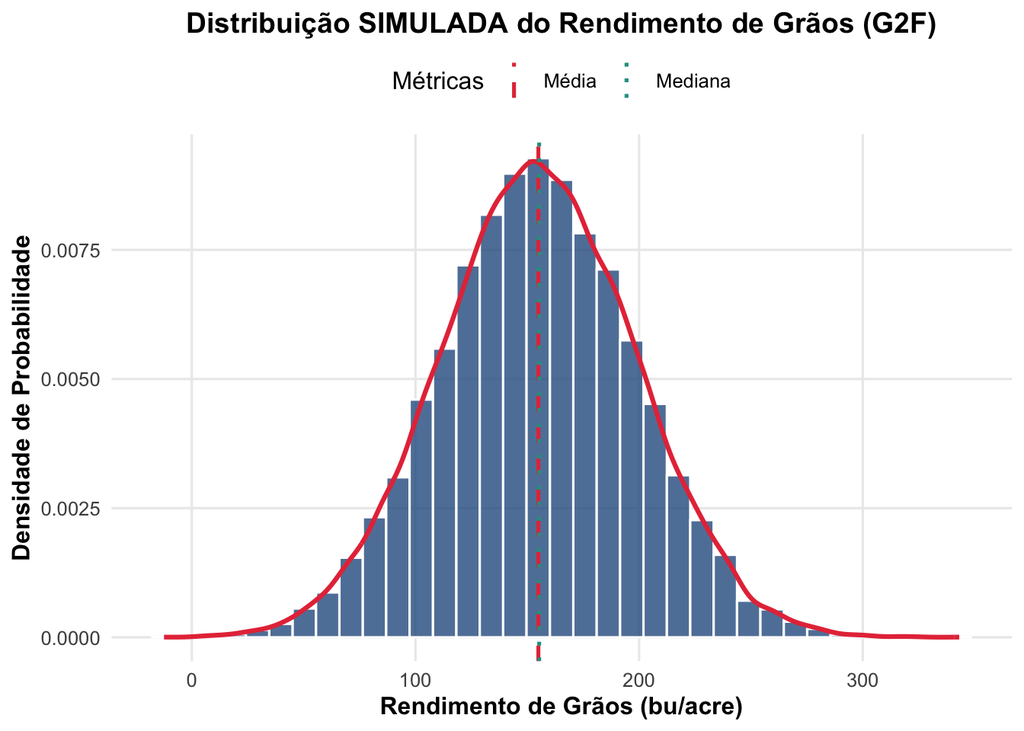

```r
#### NORMAL SIMULADA
ggplot(, aes(x = normal_simulada)) +
  geom_histogram(
    aes(y = after_stat(density)),
    bins = 35,
    fill = "#2b5c8f",
    color = "white",
    alpha = 0.8
  ) +
  geom_density(color = "#e63946", linewidth = 1.1) +
  geom_vline(
    aes(xintercept = media_prod, linetype = "Média"),
    color = "#e63946", linewidth = 0.9
  ) +
  geom_vline(
    aes(xintercept = mediana_prod, linetype = "Mediana"),
    color = "#2a9d8f", linewidth = 0.9
  ) +
  scale_linetype_manual(
    name = "Métricas",
    values = c("Média" = "dashed", "Mediana" = "dotted")
  ) +
  labs(
    title = "Distribuição SIMULADA do Rendimento de Grãos (G2F)",
    x = "Rendimento de Grãos (bu/acre)",
    y = "Densidade de Probabilidade"
  ) +
  theme_minimal(base_size = 12) +
  theme(
    plot.title = element_text(face = "bold", size = 14, hjust = 0.5),
    plot.subtitle = element_text(size = 10, hjust = 0.5, color = "gray30"),
    axis.title = element_text(face = "bold"),
    legend.position = "top",
    panel.grid.minor = element_blank()
  )
```